# airbnb-milano-analysis

## Regression with LASSO

```r
#LASSO
# take models 5 (the best) and model 6 (overfit)
vars_model_5 <- c("price", basic_lev,basic_add,reviews,poly_lev,X1,amenities)
vars_model_6 <- c("price", basic_lev,basic_add,reviews,poly_lev,X1,amenities,X2)

# Set lasso tuning parameters
train_control <- trainControl(method = "cv", number = n_folds)
tune_grid <- expand.grid("alpha" = c(1), "lambda" = seq(0.05, 1, by = 0.05))

# Use model 6
formula <- formula(paste0("price ~ ", paste(setdiff(vars_model_6, "price"), collapse = " + ")))

set.seed(20180124)
lasso_model <- caret::train(formula,
                      data = data_work,
                      method = "glmnet",
                      preProcess = c("center", "scale"),
                      trControl = train_control,
                      tuneGrid = tune_grid,
                    na.action=na.exclude)

print(lasso_model$bestTune$lambda)
```

```
## [1] 0.5
```

```r
lasso_coeffs <- coef(lasso_model$finalModel, lasso_model$bestTune$lambda) %>%
  as.matrix() %>%
  as.data.frame() %>%
  rownames_to_column(var = "variable") %>%
  rename(coefficient = `s1`)  # the column has a name "s1", to be renamed

print(lasso_coeffs)
```

```
##                                                  variable   coefficient
## 1                                             (Intercept) 133.021428892
## 2                                          n_accommodates   2.255441977
## 3                                 f_room_typePrivate room -14.927938412
## 4                                  f_room_typeShared room   0.000000000
## 5                                   f_municipioMunicipio2 -15.181812775
## 6                                 f_municipioMunicipio2-9  -0.193156845
## 7                                   f_municipioMunicipio3  -8.153352648
## 8                                   f_municipioMunicipio4  -7.683335809
## 9                                   f_municipioMunicipio5  -8.166217519
## 10                                  f_municipioMunicipio6  -0.039733517
## 11                                  f_municipioMunicipio7  -7.700638942
## 12                                  f_municipioMunicipio8   0.000000000
## 13                                  f_municipioMunicipio9  -3.612240134
## 14                                                 n_beds   1.469867248
```

[output cut: 925 more lines]

```r
lasso_coeffs_nz<-lasso_coeffs %>%
  filter(coefficient!=0)
print(nrow(lasso_coeffs_nz))
```

```
## [1] 361
```

```r
# Evaluate model. CV error:
lasso_cv_rmse <- lasso_model$results %>%
  filter(lambda == lasso_model$bestTune$lambda) %>%
  dplyr::select(RMSE)
print(lasso_cv_rmse[1, 1])
```

```
## [1] 101.8056
```

### Diagnostics

After choosing M5 as the best model, I want to evaluate the actual prediction with post-prediction diagnostics. First, I calculate the RMSE of this model in the Holdout set. The RMSE is lower than in the cross validation. I also look at the resulting RMSE in the Holdout set when using LASSO. It is again lower than the cross validation, quite close to that from M5. Therefore, I perform the diagnostic analysis on M5. From the first graph, it can be noticed that most of the low prices are quite well predicted, but the high prices are wrongly predicted. In the bar chart of price variation by size, it emerges that the model generates very wide 80% PI intervals. Therefore, predictions are quite imprecise.

```r
#Diagnostics on M5
#model2_level <- model_results_cv[["modellev2"]][["model_work_data"]]
model5_level <- model_results_cv[["modellev5"]][["model_work_data"]]
# look at holdout RMSE
model5_level_work_rmse <- mse_lev(predict(model5_level, newdata = data_work), data_work[,"price"])**(1/2)
model5_level_holdout_rmse <- mse_lev(predict(model5_level, newdata = data_holdout), data_holdout[,"price"])**(1/2)
model5_level_holdout_rmse
```

```
## [1] 94.5183
```

```r
#look at holdout RMSE using LASSO
model_lasso_holdout_rmse <- mse_lev(predict(lasso_model, newdata = data_holdout), data_holdout[,"price"])**(1/2)
model_lasso_holdout_rmse
```

```
## [1] 93.36076
```

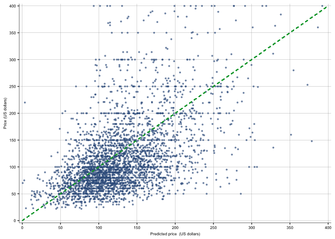

```r
#LASSO gives a slightly lower RMSE

# Figures for fitted vs actual outcome variables
# Target variable
Ylev <- data_holdout[["price"]]

meanY <-mean(Ylev)
sdY <- sd(Ylev)
meanY_m2SE <- meanY -1.96 * sdY
meanY_p2SE <- meanY + 1.96 * sdY
Y5p <- quantile(Ylev, 0.05, na.rm=TRUE)
Y95p <- quantile(Ylev, 0.95, na.rm=TRUE)

# Predicted values
predictionlev_holdout_pred <- as.data.frame(predict(model5_level, newdata = data_holdout, interval="predict")) %>% rename(pred_lwr = lwr, pred_upr = upr)
predictionlev_holdout_conf <- as.data.frame(predict(model5_level, newdata = data_holdout, interval="confidence")) %>% rename(conf_lwr = lwr, conf_upr = upr)

predictionlev_holdout <- cbind(data_holdout[,c("price","n_accommodates")],
                               predictionlev_holdout_pred,
                               predictionlev_holdout_conf[,c("conf_lwr","conf_upr")])


# Create data frame with the real and predicted values
d <- data.frame(ylev=Ylev, predlev=predictionlev_holdout[,"fit"] )
# Check the differences
d$elev <- d$ylev - d$predlev

# Plot predicted vs price
level_vs_pred <- ggplot(data = d) +
  geom_point(aes(y=ylev, x=predlev), color = color[1], size = 1,
             shape = 16, alpha = 0.7, show.legend=FALSE, na.rm=TRUE) +
  #geom_smooth(aes(y=ylev, x=predlev), method="lm", color=color[2], se=F, size=0.8, na.rm=T)+
  geom_segment(aes(x = 0, y = 0, xend = 400, yend =400), size=0.5, color=color[2], linetype=2) +
  coord_cartesian(xlim = c(0, 400), ylim = c(0, 400)) +
  scale_x_continuous(expand = c(0.01,0.01),limits=c(0, 400), breaks=seq(0, 400, by=50)) +
  scale_y_continuous(expand = c(0.01,0.01),limits=c(0, 400), breaks=seq(0, 400, by=50)) +
  labs(y = "Price (US dollars)", x = "Predicted price  (US dollars)") +
  theme_bg()
level_vs_pred
```

```r
save_fig("Airbnb-level-vs-pred", output, "small")
```

```r
# Redo predicted values at 80% PI
predictionlev_holdout_pred <- as.data.frame(predict(model5_level, newdata = data_holdout, interval="predict", level=0.8)) %>%
  rename(pred_lwr = lwr, pred_upr = upr)
predictionlev_holdout_conf <- as.data.frame(predict(model5_level, newdata = data_holdout, interval="confidence", level=0.8)) %>%
  rename(conf_lwr = lwr, conf_upr = upr)

predictionlev_holdout <- cbind(data_holdout[,c("price","n_accommodates")],
                               predictionlev_holdout_pred,
                               predictionlev_holdout_conf[,c("conf_lwr","conf_upr")])

summary(predictionlev_holdout_pred)
```

```
##       fit            pred_lwr            pred_upr
##  Min.   :-23.43   Min.   :-154.9169   Min.   :108.0
##  1st Qu.: 94.09   1st Qu.: -36.9340   1st Qu.:225.3
##  Median :122.78   Median :  -8.4564   Median :253.9
##  Mean   :131.49   Mean   :   0.3232   Mean   :262.7
##  3rd Qu.:160.14   3rd Qu.:  29.1308   3rd Qu.:291.3
##  Max.   :439.99   Max.   : 308.4594   Max.   :571.5
```

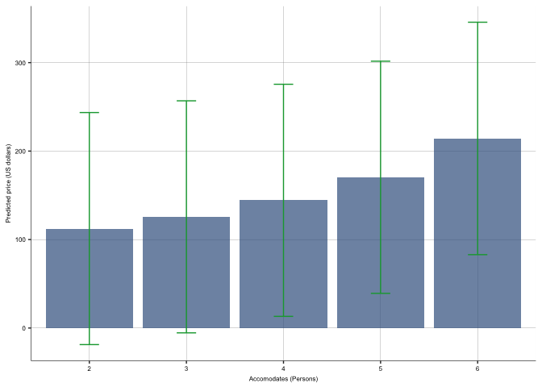

```r
predictionlev_holdout_summary <-
  predictionlev_holdout %>%
  group_by(n_accommodates) %>%
  dplyr::summarise(fit = mean(fit, na.rm=TRUE), pred_lwr = mean(pred_lwr, na.rm=TRUE), pred_upr = mean(pred_upr, na.rm=TRUE),
            conf_lwr = mean(conf_lwr, na.rm=TRUE), conf_upr = mean(conf_upr, na.rm=TRUE))

kable(x = predictionlev_holdout_summary, format = "latex", booktabs=TRUE,  digits = 3, row.names = FALSE,
      linesep = "", col.names = c("Accomodates","Prediction","Pred. interval lower",
                                  "Pred. interval upper","Conf.interval lower","Conf.interval upper")) %>%
  cat(.,file= paste0(output, "modellev7_holdout_summary.tex"))


CI_n_accomodate <- ggplot(predictionlev_holdout_summary, aes(x=factor(n_accommodates))) +
  geom_bar(aes(y = fit ), stat="identity",  fill = color[1], alpha=0.7 ) +
  geom_errorbar(aes(ymin=pred_lwr, ymax=pred_upr, color = "Pred. interval"),width=.2) +
  #geom_errorbar(aes(ymin=conf_lwr, ymax=conf_upr, color = "Conf. interval"),width=.2) +
  scale_y_continuous(name = "Predicted price (US dollars)") +
  scale_x_discrete(name = "Accomodates (Persons)") +
  scale_color_manual(values=c(color[2], color[2])) +
  theme_bg() +
  theme(legend.title= element_blank(),legend.position="none")
CI_n_accomodate
```

```r
save_fig("airbnb-ci-n-accomodate", output, "small")
```

## Random forest

This is an ensemble method that combines the results of hundreds of regression trees. One of the great advantages of Random forest is that variable selection, interaction picking, and functional form decisions are not needed. ### Set up I keep the same working data and holdout set, same combinations of variables and I predict 3 models with RF: - RF1. basic vars - RF2. RF1 + reviews + amenities (benchmark model, similar to M5 but no interactions or polynomials) - RFE. equal to M6 (for LASSO)

```r
#use same train(work) and holdout

dim(data_work)
```

```
## [1] 13360    90
```

```r
dim(data_holdout)
```

```
## [1] 3340   90
```

```r
#basic_lev
#basic_add
basic_vars <- c(basic_lev,basic_add)
#reviews
#amenities
#X1,X2

predictors_1 <- c(basic_vars) #RF1
predictors_2 <- c(basic_vars, reviews, amenities) #RF2
predictors_E <- c(basic_vars, reviews, X1, amenities, X2) #RFE
```

## Cross-validation

```r
# do 5-fold CV
train_control <- trainControl(method = "cv",
                              number = 5,
                              verboseIter = FALSE)


# set tuning
tune_grid <- expand.grid(
  .mtry = c(5, 7, 9),
  .splitrule = "variance",
  .min.node.size = c(5, 10)
)


# simpler model for model A (1)
set.seed(20180124)
system.time({
rf_model_1 <- train(
  formula(paste0("price ~", paste0(predictors_1, collapse = " + "))),
  data = data_work,
  method = "ranger",
  trControl = train_control,
  tuneGrid = tune_grid,
  importance = "impurity"
)
})
```

```
##    user  system elapsed
## 443.121   9.711 138.436
```

```r
rf_model_1
```

```
## Random Forest
##
## 13360 samples
##     8 predictor
##
## No pre-processing
## Resampling: Cross-Validated (5 fold)
## Summary of sample sizes: 10688, 10687, 10689, 10688, 10688
## Resampling results across tuning parameters:
##
##   mtry  min.node.size  RMSE      Rsquared   MAE
##   5      5             105.9813  0.1710488  60.67305
##   5     10             105.7536  0.1737269  60.48839
##   7      5             107.1526  0.1604417  61.50362
##   7     10             106.4369  0.1678089  61.03568
##   9      5             108.4155  0.1503808  62.38012
##   9     10             107.3866  0.1593049  61.71079
##
## Tuning parameter 'splitrule' was held constant at a value of variance
## RMSE was used to select the optimal model using the smallest value.
## The final values used for the model were mtry = 5, splitrule = variance
##  and min.node.size = 10.
```

```r
# set tuning for benchamrk model (2)
tune_grid <- expand.grid(
  .mtry = c(8, 10, 12),
  .splitrule = "variance",
  .min.node.size = c(5, 10, 15)
)

set.seed(20180124)
system.time({
rf_model_2 <- train(
  formula(paste0("price ~", paste0(predictors_2, collapse = " + "))),
  data = data_work,
  method = "ranger",
  trControl = train_control,
  tuneGrid = tune_grid,
  importance = "impurity"
)
})
```

```
##     user   system  elapsed
## 1657.022   33.854  510.414
```

```r
rf_model_2
```

```
## Random Forest
##
## 13360 samples
##    68 predictor
##
## No pre-processing
## Resampling: Cross-Validated (5 fold)
## Summary of sample sizes: 10688, 10687, 10689, 10688, 10688
## Resampling results across tuning parameters:
##
##   mtry  min.node.size  RMSE       Rsquared   MAE
##    8     5              99.61711  0.2717790  57.21484
##    8    10              99.95804  0.2688496  57.40622
##    8    15             100.32111  0.2660056  57.68398
##   10     5              99.47752  0.2711869  57.19160
##   10    10              99.91459  0.2662929  57.40352
##   10    15             100.09189  0.2662778  57.55387
##   12     5              99.63845  0.2671101  57.29645
##   12    10              99.81713  0.2657821  57.43765
##   12    15             100.12517  0.2629380  57.54372
##
## Tuning parameter 'splitrule' was held constant at a value of variance
## RMSE was used to select the optimal model using the smallest value.
## The final values used for the model were mtry = 10, splitrule = variance
##  and min.node.size = 5.
```

```r
# auto tuning first
 set.seed(20180124)
 system.time({
   rf_model_2auto <- train(
     formula(paste0("price ~", paste0(predictors_2, collapse = " + "))),
     data = data_work,
     method = "ranger",
     trControl = train_control,
     importance = "impurity"
   )
 })
```

```
##     user   system  elapsed
## 4504.155   68.738 2464.827
```

```r
 rf_model_2auto
```

```
## Random Forest
##
## 13360 samples
##    68 predictor
##
## No pre-processing
## Resampling: Cross-Validated (5 fold)
## Summary of sample sizes: 10688, 10687, 10689, 10688, 10688
## Resampling results across tuning parameters:
##
##   mtry  splitrule   RMSE      Rsquared   MAE
##    2    variance    106.2834  0.2453991  61.83610
##    2    extratrees  107.2634  0.2394702  62.69617
##   41    variance    101.4091  0.2443045  58.72077
##   41    extratrees  101.0950  0.2475901  58.68595
##   80    variance    103.1022  0.2283410  59.68089
##   80    extratrees  102.7049  0.2316421  59.69503
##
## Tuning parameter 'min.node.size' was held constant at a value of 5
## RMSE was used to select the optimal model using the smallest value.
## The final values used for the model were mtry = 41, splitrule = extratrees
##  and min.node.size = 5.
```

```r
#rf_model_2auto <-rf_model_2


# evaluate random forests

results <- resamples(
  list(
    model_1  = rf_model_1,
    model_2  = rf_model_2,
    model_2b = rf_model_2auto
  )
)
summary(results)
```

```
##
## Call:
## summary.resamples(object = results)
##
## Models: model_1, model_2, model_2b
## Number of resamples: 5
##
## MAE
##              Min.  1st Qu.   Median     Mean  3rd Qu.     Max. NA's
## model_1  57.63939 60.31503 61.05196 60.48839 61.10929 62.32629    0
## model_2  55.47729 56.08009 57.56513 57.19160 58.15428 58.68119    0
## model_2b 57.10848 57.20506 59.56975 58.68595 59.69732 59.84911    0
##
## RMSE
##              Min.   1st Qu.    Median      Mean  3rd Qu.     Max. NA's
## model_1  99.80735 104.86453 106.94681 105.75364 108.3711 108.7784    0
## model_2  96.17641  96.54628  97.41396  99.47752 103.5030 103.7480    0
## model_2b 98.12821  98.58281  99.27386 101.09499 104.3224 105.1677    0
##
## Rsquared
##               Min.   1st Qu.    Median      Mean   3rd Qu.      Max. NA's
## model_1  0.1655683 0.1692513 0.1694723 0.1737269 0.1779961 0.1863467    0
## model_2  0.2333920 0.2419033 0.2497184 0.2711869 0.3105071 0.3204139    0
## model_2b 0.2104326 0.2227036 0.2374774 0.2475901 0.2811375 0.2861993    0
```

```r
# Save outputs

# Show Model 2B rmse shown with all the combinations
rf_tuning_modelB <- rf_model_2$results %>%
  dplyr::select(mtry, min.node.size, RMSE) %>%
  dplyr::rename(nodes = min.node.size) %>%
  spread(key = mtry, value = RMSE)

kable(x = rf_tuning_modelB, format = "latex", digits = 2, caption = "CV RMSE") %>%
  add_header_above(c(" ", "vars" = 3)) %>%
  cat(.,file= paste0(output,"rf_tuning_modelB.tex"))


# Turning parameter choice 1
result_1 <- matrix(c(
                     rf_model_1$finalModel$mtry,
                     rf_model_2$finalModel$mtry,
                     rf_model_2auto$finalModel$mtry,
                     rf_model_1$finalModel$min.node.size,
                     rf_model_2$finalModel$min.node.size,
                     rf_model_2auto$finalModel$min.node.size

                     ),
                    nrow=3, ncol=2,
                    dimnames = list(c("Model A", "Model B","Model B auto"),
                                    c("Min vars","Min nodes"))
                   )
kable(x = result_1, format = "latex", digits = 3) %>%
  cat(.,file= paste0(output,"rf_models_turning_choices.tex"))

# Turning parameter choice 2
result_2 <- matrix(c(mean(results$values$`model_1~RMSE`),
                     mean(results$values$`model_2~RMSE`),
                     mean(results$values$`model_2b~RMSE`)
),
nrow=3, ncol=1,
dimnames = list(c("Model A", "Model B","Model B auto"),
                c(results$metrics[2]))
)


kable(x = result_2, format = "latex", digits = 3) %>%
   cat(.,file= paste0(output,"rf_models_rmse.tex"))
```

## Diagnostics

Random forest cannot be interepreted as it is. Diagnostics are possible on the holdout set: 1. Variable importance plot - shows average improvements in fit when variables are used to split the data - top 10 - grouping factor variables 2. Partial dependence plot - shows how average predicted price differs for different values of a variable conditional on all other predictors 3. Subsample performance - for external validity The most important variables are number of bathrooms, days in operations, municipi, number of accommodates. Moverover, conditionally on the rest, the average predicted price seems to be close to constant across Municipi, while there is a particular relation between average predicted prices and number or bathrooms, which looks like half of a parabola, i.e. it is far from being linear. Finally, the prediction works best (lower RMSE/mean(price)) for apartment size (number of accommodates), municipi, and entire places, not for private or shared rooms. Hence, the our prediction would be best used for the former types of observations only, while more information is needed to be able to make relevant decisions based on the less well predicted groups.

[figure not shown]

```r
# Variable Importance Plots
# first need a function to calculate grouped varimp
group.importance <- function(rf.obj, groups) {
  var.imp <- as.matrix(sapply(groups, function(g) {
    sum(importance(rf.obj)[g], na.rm = TRUE)
  }))
  colnames(var.imp) <- "MeanDecreaseGini"
  return(var.imp)
}


# variable importance plot
# 1) full varimp plot, full
# 2) varimp plot , top 10
# 3) varimp plot grouped
# 4) varimp plot  w copy, top 10


rf_model_2_var_imp <- importance(rf_model_2$finalModel)/1000
rf_model_2_var_imp_df <-
  data.frame(varname = names(rf_model_2_var_imp),imp = rf_model_2_var_imp) %>%
  mutate(varname = gsub("f_municipio", "Borough:", varname) ) %>%
  mutate(varname = gsub("f_room_type", "Room type:", varname) ) %>%
  arrange(desc(imp)) %>%
  mutate(imp_percentage = imp/sum(imp))



# 1) full varimp plot, above a cutoff

# to have a quick look
plot(varImp(rf_model_2))
```

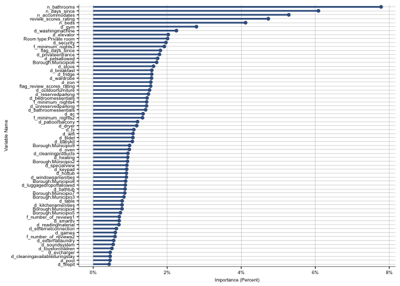

```r
cutoff = 600
rf_model_2_var_imp_plot <- ggplot(rf_model_2_var_imp_df[rf_model_2_var_imp_df$imp>cutoff,],
                                  aes(x=reorder(varname, imp), y=imp_percentage)) +
  geom_point(color=color[1], size=1.5) +
  geom_segment(aes(x=varname,xend=varname,y=0,yend=imp_percentage), color=color[1], size=1) +
  ylab("Importance (Percent)") +
  xlab("Variable Name") +
  coord_flip() +
  scale_y_continuous(labels = scales::percent_format(accuracy = 1)) +
  theme_bg() +
  theme(axis.text.x = element_text(size=6), axis.text.y = element_text(size=6),
        axis.title.x = element_text(size=6), axis.title.y = element_text(size=6))
rf_model_2_var_imp_plot
```

```r
#save_fig("rf_varimp1",output, "large")
save_fig("Airbnb-rf-varimp-base",output, "large")
```

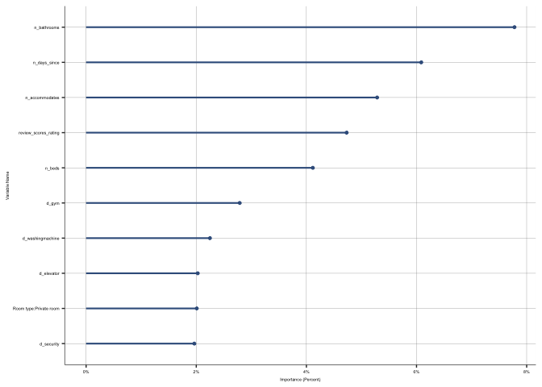

```r
# 2) full varimp plot, top 10 only

# have a version with top 10 vars only
rf_model_2_var_imp_plot_b <- ggplot(rf_model_2_var_imp_df[1:10,], aes(x=reorder(varname, imp), y=imp_percentage)) +
  geom_point(color=color[1], size=1) +
  geom_segment(aes(x=varname,xend=varname,y=0,yend=imp_percentage), color=color[1], size=0.75) +
  ylab("Importance (Percent)") +
  xlab("Variable Name") +
  coord_flip() +
  scale_y_continuous(labels = scales::percent_format(accuracy = 1)) +
  theme_bg() +
  theme(axis.text.x = element_text(size=4), axis.text.y = element_text(size=4),
        axis.title.x = element_text(size=4), axis.title.y = element_text(size=4))
rf_model_2_var_imp_plot_b
```

```r
#save_fig("rf_varimp1_b",output, "small")
save_fig("Airbnb-rf-varimp-top10",output, "small")
```

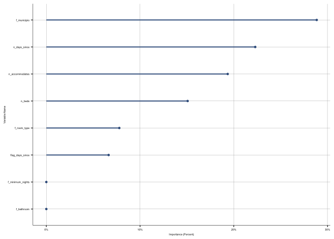

```r
# 3) varimp plot grouped

# grouped variable importance - keep binaries created off factors together

varnames <- rf_model_2$finalModel$xNames
f_municipio_varnames <- grep("f_municipio",varnames, value = TRUE)
f_room_type_varnames <- grep("f_room_type",varnames, value = TRUE)

groups <- list(f_municipio=f_municipio_varnames,
               f_room_type = f_room_type_varnames,
               f_bathroom = "n_bathroom",
               n_days_since = "n_days_since",
               n_accommodates = "n_accommodates",
               n_beds = "n_beds",
               f_minimum_nights = "f_minimum_nights",
               flag_days_since = "flag_days_since")

rf_model_2_var_imp_grouped <- group.importance(rf_model_2$finalModel, groups)
rf_model_2_var_imp_grouped_df <- data.frame(varname = rownames(rf_model_2_var_imp_grouped),
                                            imp = rf_model_2_var_imp_grouped[,1])  %>%
  mutate(imp_percentage = imp/sum(imp))

rf_model_2_var_imp_grouped_plot <-
  ggplot(rf_model_2_var_imp_grouped_df, aes(x=reorder(varname, imp), y=imp_percentage)) +
  geom_point(color=color[1], size=1) +
  geom_segment(aes(x=varname,xend=varname,y=0,yend=imp_percentage), color=color[1], size=0.7) +
  ylab("Importance (Percent)") +   xlab("Variable Name") +
  coord_flip() +
  # expand=c(0,0),
  scale_y_continuous(labels = scales::percent_format(accuracy = 1)) +
theme_bg() +
  theme(axis.text.x = element_text(size=4), axis.text.y = element_text(size=4),
        axis.title.x = element_text(size=4), axis.title.y = element_text(size=4))
rf_model_2_var_imp_grouped_plot
```

```r
save_fig("Airbnb-rf-varimp-group",output, "small")
```

```
## `geom_line()`: Each group consists of only one observation.
## ℹ Do you need to adjust the group aesthetic?
```

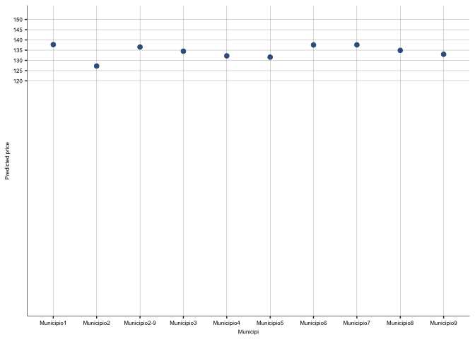

```r
# Partial Dependence Plots

pdp_f_muni <- pdp::partial(rf_model_2, pred.var = "f_municipio", pred.grid = distinct_(data_holdout, "f_municipio"), train = data_work)
pdp_f_muni_plot <- pdp_f_muni %>%
   autoplot( ) +
  geom_point(color=color[1], size=2) +
  ylab("Predicted price") +
  xlab("Municipi") +
  scale_y_continuous(limits=c(12,150), breaks=seq(120,150, by=5)) +
  theme_bg()
pdp_f_muni_plot
```

```r
save_fig("Airbnb-rf-pdp-f-municipi", output, "small")
```

```
## `geom_line()`: Each group consists of only one observation.
## ℹ Do you need to adjust the group aesthetic?
## `geom_line()`: Each group consists of only one observation.
## ℹ Do you need to adjust the group aesthetic?
```

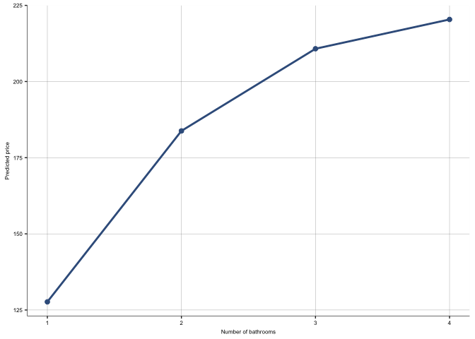

```r
pdp_n_bathrooms <- pdp::partial(rf_model_2, pred.var = "n_bathrooms", pred.grid = distinct_(data_holdout, "n_bathrooms"), train = data_work)
pdp_n_bathrooms_plot <- pdp_n_bathrooms %>%
   autoplot( ) +
  geom_point(color=color[1], size=2) +
  geom_line(color=color[1], size=1) +
  ylab("Predicted price") +
  xlab("Number of bathrooms") +
  scale_x_continuous(limit=c(1,4), breaks=seq(1,4,1))+
theme_bg()
pdp_n_bathrooms_plot
```

```r
save_fig("Airbnb-rf-pdp-bathrooms", output, "small")
```

```r
# Subsample performance: RMSE / mean(y)
# On the holdout set

# ---- cheaper or more expensive flats - not used in book
data_holdout_w_prediction <- data_holdout %>%
  mutate(predicted_price = predict(rf_model_2, newdata = data_holdout))

######### create nice summary table of heterogeneity
a <- data_holdout_w_prediction %>%
  mutate(is_low_size = ifelse(n_accommodates <= 3, "small apt", "medium apt")) %>%
  group_by(is_low_size) %>%
  dplyr::summarise(
    rmse = RMSE(predicted_price, price),
    mean_price = mean(price),
    rmse_norm = RMSE(predicted_price, price) / mean(price)
  )

#3 richest, 3 poorest
b <- data_holdout_w_prediction %>%
  filter(f_municipio %in% c("Municipio1", "Municipio3", "Municipio2", "Municipio8", "Municipio7", "Municipio9")) %>%
  group_by(f_municipio) %>%
  dplyr::summarise(
    rmse = RMSE(predicted_price, price),
    mean_price = mean(price),
    rmse_norm = rmse / mean_price
  )

c <- data_holdout_w_prediction %>%
  filter(f_room_type %in% c("Entire home/apt", "Private room", "Shared room")) %>%
  group_by(f_room_type) %>%
  dplyr::summarise(
    rmse = RMSE(predicted_price, price),
    mean_price = mean(price),
    rmse_norm = rmse / mean_price
  )


d <- data_holdout_w_prediction %>%
  dplyr::summarise(
    rmse = RMSE(predicted_price, price),
    mean_price = mean(price),
    rmse_norm = RMSE(predicted_price, price) / mean(price)
  )

# Save output
colnames(a) <- c("", "RMSE", "Mean price", "RMSE/price")
colnames(b) <- c("", "RMSE", "Mean price", "RMSE/price")
colnames(c) <- c("", "RMSE", "Mean price", "RMSE/price")
d<- cbind("All", d)
colnames(d) <- c("", "RMSE", "Mean price", "RMSE/price")

line1 <- c("Type", "", "", "")
line2 <- c("Apartment size", "", "", "")
line3 <- c("Borough", "", "", "")

result_3 <- rbind(line2, a, line1, c, line3, b, d) %>%
  transform(RMSE = as.numeric(RMSE), `Mean price` = as.numeric(`Mean price`),
            `RMSE/price` = as.numeric(`RMSE/price`))

options(knitr.kable.NA = '')
kable(x = result_3, format = "latex", booktabs=TRUE, linesep = "",digits = c(0,2,1,2), col.names = c("","RMSE","Mean price","RMSE/price")) %>%
  cat(.,file= paste0(output, "performance_across_subsamples.tex"))
options(knitr.kable.NA = NULL)
```

## Horserace

```r
# OLS with dummies for area
# using model B

set.seed(20180124)
system.time({
ols_model <- train(
  formula(paste0("price ~", paste0(predictors_2, collapse = " + "))),
  data = data_train,
  method = "lm",
  trControl = train_control
)
})
```

```
##    user  system elapsed
##   1.381   0.197   1.660
```

```r
ols_model_coeffs <-  ols_model$finalModel$coefficients
ols_model_coeffs_df <- data.frame(
  "variable" = names(ols_model_coeffs),
  "ols_coefficient" = ols_model_coeffs
) %>%
  mutate(variable = gsub("`","",variable))

# * LASSO
# using extended model w interactions

set.seed(20180124)
system.time({
lasso_model2 <- train(
  formula(paste0("price ~", paste0(predictors_E, collapse = " + "))),
  data = data_train,
  method = "glmnet",
  preProcess = c("center", "scale"),
  tuneGrid =  expand.grid("alpha" = 1, "lambda" = seq(0.01, 0.25, by = 0.01)),
  trControl = train_control
)
})
```

```
##    user  system elapsed
##  69.262   7.416  82.868
```

```r
lasso_coeffs2 <- coef(
    lasso_model2$finalModel,
    lasso_model2$bestTune$lambda) %>%
  as.matrix() %>%
  as.data.frame() %>%
  rownames_to_column(var = "variable") %>%
  rename(lasso_coefficient = `s1`)  # the column has a name "1", to be renamed

lasso_coeffs_non_null2 <- lasso_coeffs2[!lasso_coeffs2$lasso_coefficient == 0,]

regression_coeffs <- merge(ols_model_coeffs_df, lasso_coeffs_non_null2, by = "variable", all=TRUE)
regression_coeffs %>%
  write.csv(file = paste0(output, "regression_coeffs.csv"))

# ---- compare these models

final_models <-
  list("OLS" = ols_model,
  "LASSO (model w/ interactions)" = lasso_model2,
  "Random forest (smaller model)" = rf_model_1,
  "Random forest" = rf_model_2,
  "Random forest (auto tuned)" = rf_model_2auto)

results <- resamples(final_models) %>% summary()


# Save output
# Model selection is carried out on this CV RMSE

result_4 <- imap(final_models, ~{
  mean(results$values[[paste0(.y,"~RMSE")]])
}) %>% unlist() %>% as.data.frame() %>%
  rename("CV RMSE" = ".")

kable(x = result_4, format = "latex", digits = 3, booktabs=TRUE, linesep = "") %>%
  cat(.,file= paste0(output,"horse_race_of_models_cv_rmse.tex"))


# evaluate preferred model on the holdout set

result_5 <- map(final_models, ~{
  RMSE(predict(.x, newdata = data_holdout), data_holdout[["price"]])
}) %>% unlist() %>% as.data.frame() %>%
  rename("Holdout RMSE" = ".")

kable(x = result_5, format = "latex", digits = 3, booktabs=TRUE, linesep = "") %>%
  cat(.,file= paste0(output,"horse_race_of_models_houldout_rmse.tex"))
```